# Image Classification using CNNs in Keras

```python
https://github.com/GreatLearningAIML1/gl-pgp-aiml-uta-intl-may20-embedevelop/tree/master/Introduction-ComputerVision
```

# Overview The plant seedlings images of 12 plant species. Determine plant's species from a photo. The images are in images.npy file and labels are put into Labels.csv.

# 1. Import the libraries, load dataset, print shape of data, visualize the images in dataset

```python
import cv2
import numpy as np
import pandas as pd
import tensorflow as tf
import matplotlib.pyplot as plt
import sys
%matplotlib inline

from keras.utils import np_utils
from sklearn import preprocessing

from tensorflow.keras import datasets, models, layers, optimizers
from tensorflow.keras.preprocessing.image import ImageDataGenerator
from tensorflow.keras.callbacks import ModelCheckpoint, EarlyStopping
from google.colab.patches import cv2_imshow
```

```python
from google.colab import drive
drive.mount('/content/drive/')
```

```python
labels = pd.read_csv('/content/drive/My Drive/Colab Notebooks/ComputerVision/Exam/Labels.csv', encoding="utf-8", header = 0)
labeling = labels.copy()
labeling = labeling.to_numpy()
print(labels.shape)
```

```
(4750, 1)
```

```python
from sklearn.preprocessing import LabelEncoder   # import label encoder
labelencoder = LabelEncoder()
labels['Label'] = labelencoder.fit_transform(labels.Label) # returns label encoded variable(s)
labels = labels.to_numpy()
print(labels.shape)
```

```
(4750, 1)
```

```python
DATA_PATH = '/content/drive/My Drive/Colab Notebooks/ComputerVision/Exam/images.npy'
images = np.load(DATA_PATH)
print(images.shape)
```

```
(4750, 128, 128, 3)
```

# 2. Data Pre-processing

### a. Normalization

```python
normalized = []
for img in images:
  normalization = img/255
  normalized.append(normalization)
normalizedImg = np.asarray(normalized)
normalizedImg.shape
```

```
(4750, 128, 128, 3)
```

### b. Gaussian Blurring

```python
blurredImg = []
for img in normalizedImg:
  gaussian_blurring = cv2.GaussianBlur(img, (5,5), 0)
  blurredImg.append(gaussian_blurring)
gaussianImg = np.asarray(blurredImg)
gaussianImg.shape
```

```
(4750, 128, 128, 3)
```

### c. Visialize data after pre-processing

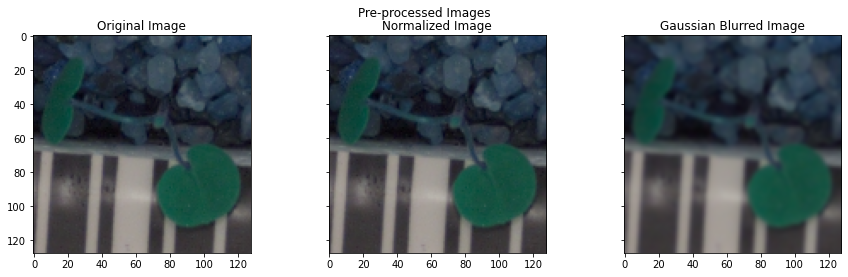

```python
i = 10
original = images[i]
normalized = normalizedImg[i]
gaussian = gaussianImg[i]
# Origianl Image vs Gaussian Image
plant, (axis1, axis2, axis3) = plt.subplots(1, 3, sharey=True)
plant.set_figwidth(15)
axis1.set_title('Original Image')
axis1.imshow(original)
axis2.set_title('Normalized Image')
axis2.imshow(normalized)
axis3.set_title('Gaussian Blurred Image')
axis3.imshow(gaussian)
plant.suptitle("Pre-processed Images")
```

[figure not shown]

```python
# plotting some random 10 images
import matplotlib.pyplot as plt

class_names = ['Small-flowered Cranesbill','Fat Hen','Shepherds Purse','Common wheat','Common Chickweed',
               'Charlock','Cleavers','Scentless Mayweed','Sugar beet','Maize', 'Black-grass', 'Loose Silky-bent']

fig = plt.figure(figsize=(15,5))
for i in range(12):
    ax = fig.add_subplot(2, 6, 1 + i, xticks=[], yticks=[])
    idx = np.where(labels[:]==i)[0]
    features_idx = gaussianImg[idx,::]
    img_num = np.random.randint(features_idx.shape[0])
    im = (features_idx[img_num,::])
    ax.set_title(class_names[i])
    plt.imshow(im)
plt.show()
```

[output not shown]

# 3. Make data compatible

### a. Convert labels to one-hot-vectors

```python
from sklearn.preprocessing import LabelBinarizer
enc = LabelBinarizer()
y = enc.fit_transform(labels)
print(y.shape)
```

```
(4750, 12)
```

```python
print(y[0])
print(y[496])
print(y[972])
print(y[1203])
print(y[1424])
print(y[2035])
print(y[2425])
print(y[2712])
print(y[3228])
print(y[3613])
print(y[3834])
print(y[4097])
```

```
[0 0 0 0 0 0 0 0 0 0 1 0]
[0 0 0 0 0 1 0 0 0 0 0 0]
[0 0 0 0 0 0 0 0 0 1 0 0]
[0 0 0 0 1 0 0 0 0 0 0 0]
[0 0 0 1 0 0 0 0 0 0 0 0]
[0 1 0 0 0 0 0 0 0 0 0 0]
[0 0 1 0 0 0 0 0 0 0 0 0]
[0 0 0 0 0 0 0 0 1 0 0 0]
[0 0 0 0 0 0 0 0 0 0 0 1]
[0 0 0 0 0 0 0 1 0 0 0 0]
[1 0 0 0 0 0 0 0 0 0 0 0]
[0 0 0 0 0 0 1 0 0 0 0 0]
```

### c. Split dataset into training testing and validation set

(Hint: First split images and labels into training and testing set with test_size = 0.3. Then further split test data into test and validation set with test_size = 0.5)

```python
from sklearn.model_selection import train_test_split
X_train, X_test, y_train, y_test = train_test_split(gaussianImg, y, test_size=0.3, random_state=44)
print(X_train.shape)
print(y_train.shape)
```

```
(3325, 128, 128, 3)
(3325, 12)
```

```python
X_test, X_val, y_test, y_val = train_test_split(X_test, y_test, test_size=0.5, random_state=44)
print(X_test.shape)
print(y_test.shape)
print(X_val.shape)
print(y_val.shape)
```

```
(712, 128, 128, 3)
(712, 12)
(713, 128, 128, 3)
(713, 12)
```

### d. Check the shape of data, Reshape data into shapes compatible with Keras models if it's not ready. If it's already in the compatible shape, then comment in the notebook that it's already in compatible shape

```python
print(X_train[9, :, :, :].shape)
print(y_train[0])
```

```
(128, 128, 3)
[0 0 0 0 0 0 0 0 1 0 0 0]
```

### The test, train and validation data sets are in compatible dataset for CNN training

# 4. Building CNN

### a. Define layers

```python
# Set the CNN model

batch_size = None

model = models.Sequential()
model.add(layers.Conv2D(32, (3, 3), activation='relu', input_shape=X_train.shape[1:]))
model.add(layers.MaxPooling2D((2, 2))) # to downsample the feature maps
model.add(layers.Conv2D(64, (3, 3), activation='relu'))
model.add(layers.MaxPooling2D((2, 2)))
model.add(layers.Conv2D(128, (3, 3), activation='relu'))
model.add(layers.MaxPooling2D((2, 2)))
model.add(layers.Conv2D(128, (3, 3), activation='relu'))
model.add(layers.MaxPooling2D((2, 2)))
model.add(layers.Flatten())
model.add(layers.Dense(255, activation='relu'))
model.add(layers.Dense(12, activation='softmax'))

model.summary()
```

```
Model: "sequential"
_________________________________________________________________
Layer (type)                 Output Shape              Param #
=================================================================
conv2d (Conv2D)              (None, 126, 126, 32)      896
_________________________________________________________________
max_pooling2d (MaxPooling2D) (None, 63, 63, 32)        0
_________________________________________________________________
conv2d_1 (Conv2D)            (None, 61, 61, 64)        18496
_________________________________________________________________
max_pooling2d_1 (MaxPooling2 (None, 30, 30, 64)        0
_________________________________________________________________
conv2d_2 (Conv2D)            (None, 28, 28, 128)       73856
_________________________________________________________________
max_pooling2d_2 (MaxPooling2 (None, 14, 14, 128)       0
_________________________________________________________________
conv2d_3 (Conv2D)            (None, 12, 12, 128)       147584
_________________________________________________________________
max_pooling2d_3 (MaxPooling2 (None, 6, 6, 128)         0
_________________________________________________________________
flatten (Flatten)            (None, 4608)              0
_________________________________________________________________
dense (Dense)                (None, 255)               1175295
_________________________________________________________________
dense_1 (Dense)              (None, 12)                3072
=================================================================
Total params: 1,419,199
Trainable params: 1,419,199
Non-trainable params: 0
_________________________________________________________________
```

```python
# Conversion to float type from integer type.
X_train = X_train.astype('float32')
X_test = X_test.astype('float32')
```

### b. Set optimizer and loss function (Use Adam optimizer and categorical crossentropy)

```python
model.compile(loss='categorical_crossentropy', optimizer='adam', metrics=['accuracy'])
```

# 5. Fit and evaluate model and print confusion matrix

```python
from tensorflow.keras.callbacks import ModelCheckpoint, EarlyStopping
early_stopping = EarlyStopping(monitor='val_loss', min_delta=0.001, patience=10)
model_checkpoint =  ModelCheckpoint('cnn_checkpoint_{epoch:02d}_loss{val_loss:.4f}.h5',
                                                           monitor='val_loss',
                                                           verbose=1,
                                                           save_best_only=True,
                                                           save_weights_only=True,
                                                           mode='auto',
                                                           period=1)
```

```
WARNING:tensorflow:`period` argument is deprecated. Please use `save_freq` to specify the frequency in number of batches seen.
```

```python
history = model.fit(X_train,
                    y_train,
                    batch_size=batch_size,
                    epochs=40,
                    validation_data=(X_val, y_val),
                    shuffle=True,
                    verbose=1,
                    callbacks=[early_stopping,model_checkpoint])
```

```
Epoch 00001: val_loss improved from inf to 1.62560, saving model to cnn_checkpoint_01_loss1.6256.h5
Epoch 00002: val_loss improved from 1.62560 to 1.21747, saving model to cnn_checkpoint_02_loss1.2175.h5
Epoch 00003: val_loss improved from 1.21747 to 1.10250, saving model to cnn_checkpoint_03_loss1.1025.h5
Epoch 00004: val_loss improved from 1.10250 to 1.00186, saving model to cnn_checkpoint_04_loss1.0019.h5
Epoch 00005: val_loss improved from 1.00186 to 0.80168, saving model to cnn_checkpoint_05_loss0.8017.h5
Epoch 00006: val_loss improved from 0.80168 to 0.73757, saving model to cnn_checkpoint_06_loss0.7376.h5
Epoch 00007: val_loss improved from 0.73757 to 0.71883, saving model to cnn_checkpoint_07_loss0.7188.h5
Epoch 00008: val_loss did not improve from 0.71883
Epoch 00009: val_loss did not improve from 0.71883
Epoch 00010: val_loss did not improve from 0.71883
Epoch 00011: val_loss did not improve from 0.71883
Epoch 00012: val_loss did not improve from 0.71883
Epoch 00013: val_loss did not improve from 0.71883
Epoch 00014: val_loss did not improve from 0.71883
Epoch 00015: val_loss did not improve from 0.71883
Epoch 00016: val_loss did not improve from 0.71883
Epoch 00017: val_loss did not improve from 0.71883
```

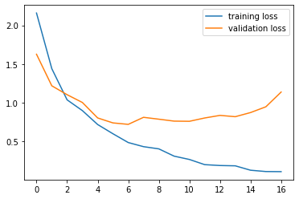

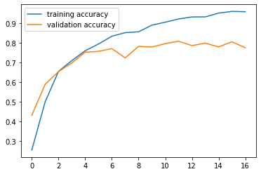

```python
# plot training history
plt.plot(history.history['loss'], label='training loss')
plt.plot(history.history['val_loss'], label='validation loss')
plt.legend()
plt.show()

plt.plot(history.history['accuracy'], label='training accuracy')
plt.plot(history.history['val_accuracy'], label='validation accuracy')
plt.legend()
plt.show()
```

```python
# Score trained model.
scores = model.evaluate(X_test, y_test, verbose=1)
print('Test loss:', scores[0])
print('Test accuracy:', scores[1])
```

```
Test loss: 1.276448130607605
Test accuracy: 0.7696629166603088
```

### Confusion Matrix

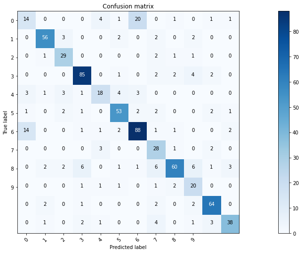

```python
from sklearn.metrics import confusion_matrix
import itertools
plt.subplots(figsize=(22,7))

def plot_confusion_matrix(cm, classes, normalize=False, title='Confusion matrix', cmap=plt.cm.Blues):
    plt.imshow(cm, interpolation='nearest', cmap=cmap)
    plt.title(title)
    plt.colorbar()
    tick_marks = np.arange(len(classes))
    plt.xticks(tick_marks, classes, rotation=45)
    plt.yticks(tick_marks, classes)

    if normalize:
        cm = cm.astype('float') / cm.sum(axis=1)[:, np.newaxis]

    thresh = cm.max() / 2.
    for i, j in itertools.product(range(cm.shape[0]), range(cm.shape[1])):
        plt.text(j, i, cm[i, j], horizontalalignment="center", color="white" if cm[i, j] > thresh else "black")

    plt.tight_layout()
    plt.ylabel('True label')
    plt.xlabel('Predicted label')

# Predict the values from the validation dataset
Y_pred = model.predict(X_val)
# Convert predictions classes to one hot vectors
Y_pred_classes = np.argmax(Y_pred,axis = 1)
# Convert validation observations to one hot vectors
Y_true = np.argmax(y_val,axis = 1)
# compute the confusion matrix
confusion_mtx = confusion_matrix(Y_true, Y_pred_classes)
# plot the confusion matrix
plot_confusion_matrix(confusion_mtx, classes = range(10))
```

# 6. Visulaize predictions for x_test[2], x_test[3], x_test[33], x_test[36], x_test[59]

```python
class_names = ['Small-flowered Cranesbill','Fat Hen','Shepherds Purse','Common wheat','Common Chickweed',
               'Charlock','Cleavers','Scentless Mayweed','Sugar beet','Maize', 'Black-grass', 'Loose Silky-bent']
```

```
Predicted label: 11
['Loose Silky-bent']
Softmax Outputs: [[2.0183121e-16 3.3182499e-07 1.7783022e-09 8.3092797e-05 1.2581078e-09
  1.9501245e-08 1.6408999e-10 4.2570761e-08 4.6993453e-08 1.0497515e-03
  3.2106994e-13 9.9886680e-01]]
1.0000001
```

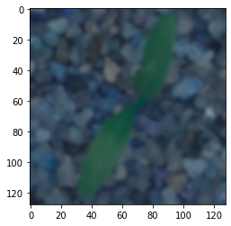

```python
%matplotlib inline
plt.imshow(X_test[2])
y_pred = model.predict(X_test[2].reshape(1, 128, 128, 3))
print("Predicted label:", y_pred.argmax())
print(str([class_names[y_pred.argmax()]]))
print("Softmax Outputs:", y_pred)
print(y_pred.sum())
```

```
Predicted label: 10
['Black-grass']
Softmax Outputs: [[3.5650521e-06 7.0445665e-08 3.7959719e-05 8.4391822e-06 3.8946948e-07
  1.6094947e-03 2.9794754e-07 2.1788332e-05 1.4570727e-09 2.7956914e-06
  9.0002930e-01 9.8285854e-02]]
0.99999994
```

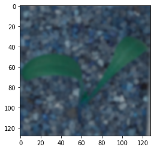

```python
plt.imshow(X_test[3])
y_pred = model.predict(X_test[3].reshape(1, 128, 128, 3))
print("Predicted label:", y_pred.argmax())
print(str([class_names[y_pred.argmax()]]))
print("Softmax Outputs:", y_pred)
print(y_pred.sum())
```

```
Predicted label: 10
['Black-grass']
Softmax Outputs: [[6.5774587e-11 1.8729479e-07 4.4548269e-08 1.8845205e-07 1.9052151e-22
  2.6768387e-08 1.6123291e-13 2.3937966e-05 1.0327457e-08 7.8067436e-10
  9.9997556e-01 2.3081324e-09]]
0.99999994
```

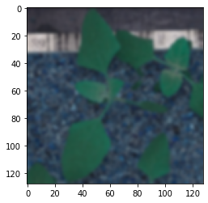

```python
plt.imshow(X_test[33])
y_pred = model.predict(X_test[33].reshape(1, 128, 128, 3))
print("Predicted label:", y_pred.argmax())
print(str([class_names[y_pred.argmax()]]))
print("Softmax Outputs:", y_pred)
print(y_pred.sum())
```

```
Predicted label: 6
['Cleavers']
Softmax Outputs: [[2.4982011e-01 5.3014620e-08 2.3449310e-07 2.3073909e-08 3.8200505e-02
  6.8255868e-05 6.8624973e-01 1.0074156e-05 2.5650971e-02 3.5861198e-13
  2.5055423e-08 5.7803469e-08]]
1.0
```

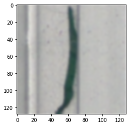

```python
plt.imshow(X_test[36])
y_pred = model.predict(X_test[36].reshape(1, 128, 128, 3))
print("Predicted label:", y_pred.argmax())
print(str([class_names[y_pred.argmax()]]))
print("Softmax Outputs:", y_pred)
print(y_pred.sum())
```

```
Predicted label: 6
['Cleavers']
Softmax Outputs: [[1.08264275e-02 8.65368020e-12 1.16855503e-09 1.28630624e-12
  1.80684185e-06 6.79447343e-09 9.89171207e-01 3.75903575e-08
  5.31067656e-07 3.36820633e-17 1.38758738e-09 2.04003303e-08]]
1.0
```

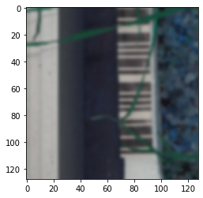

```python
plt.imshow(X_test[59])
y_pred = model.predict(X_test[59].reshape(1, 128, 128, 3))
print("Predicted label:", y_pred.argmax())
print(str([class_names[y_pred.argmax()]]))
print("Softmax Outputs:", y_pred)
print(y_pred.sum())
```